# Prosper Loans Exploration

Randy Jackson

March 5, 2018

# General Information

In the following analysis I will conduct some exploratory data analysis on the Prosper Loans data set. According to their website “Prosper is America’s first marketplace lending platform, with over $7 billion in funded loans. Prosper allows people to invest in each other in a way that is financially and socially rewarding.” See also the Prosper Homepage.

The data set at hand contains 113,937 loans with 81 variables on each loan, including loan amount, borrower rate (or interest rate), current loan status, borrower income, borrower employment status, borrower credit history, and the latest payment information. The dataset contains loans created between 2005-Q4 and 2014-Q1.

Variable Definitions for the Prosper Loans Dataset can be found here:[Variable Definitions.](https://docs.google.com/spreadsheets/d/1gDyi_L4UvIrLTEC6Wri5nbaMmkGmLQBk-Yx3z0XDEtI/edit#gid=0)

For the following analysis I will focus on 28 variables, which I pre-selected based on my subjective assumptions. I expect that those variables will reveal some interesting insights about Prosper loans.

```
##  [1] "ListingKey"
##  [2] "ListingNumber"
##  [3] "ListingCreationDate"
##  [4] "CreditGrade"
##  [5] "Term"
##  [6] "LoanStatus"
##  [7] "ClosedDate"
##  [8] "BorrowerAPR"
##  [9] "BorrowerRate"
## [10] "LenderYield"
## [11] "EstimatedEffectiveYield"
## [12] "EstimatedLoss"
## [13] "EstimatedReturn"
## [14] "ProsperRating..numeric."
## [15] "ProsperRating..Alpha."
```

[output cut: 66 more lines]

```
## Observations: 113,937
## Variables: 81
## $ ListingKey                          <fctr> 1021339766868145413AB3B, ...
## $ ListingNumber                       <int> 193129, 1209647, 81716, 65...
## $ ListingCreationDate                 <fctr> 2007-08-26 19:09:29.26300...
## $ CreditGrade                         <fctr> C, , HR, , , , , , , , , ...
## $ Term                                <int> 36, 36, 36, 36, 36, 60, 36...
## $ LoanStatus                          <fctr> Completed, Current, Compl...
## $ ClosedDate                          <fctr> 2009-08-14 00:00:00, , 20...
## $ BorrowerAPR                         <dbl> 0.16516, 0.12016, 0.28269,...
## $ BorrowerRate                        <dbl> 0.1580, 0.0920, 0.2750, 0....
## $ LenderYield                         <dbl> 0.1380, 0.0820, 0.2400, 0....
## $ EstimatedEffectiveYield             <dbl> NA, 0.07960, NA, 0.08490, ...
## $ EstimatedLoss                       <dbl> NA, 0.0249, NA, 0.0249, 0....
## $ EstimatedReturn                     <dbl> NA, 0.05470, NA, 0.06000, ...
```

[output cut: 68 more lines]

# Data Wrangling

Prior to performing my analysis I did small amount of data wrandgling to remove unused columns and convert the data set to a tibble. I used the lubridate library functionsto convert the dates from factors to dates. I also releveled LoanOriginationQuarter which appeared to be out of order. I used cut to create custom levels of DebtToIncomeRatio and corresponding factor.

```r
#Echo the creation of categorical variables per rubric

#Create a custom variable for DTI Ratio and associated factor
loans$DebtToIncomeRatioLevel<-cut(loans$DebtToIncomeRatio,
  c(0, .10, .20, .30, .40, .50), c("Excellent", "Good", "Fair", "Poor", "Bad"))

loans$DebtToIncomeRatioLevel <- factor(loans$DebtToIncomeRatioLevel,
  levels = c("Excellent", "Good", "Fair", "Poor", "Bad"))

levels(loans$DebtToIncomeRatioLevel)
```

```
## [1] "Excellent" "Good"      "Fair"      "Poor"      "Bad"
```

```r
#Echo the creation of categorical variables per rubric

#create function to rename labels
rename_listingCat <- function(i_listing) {
  #return a string with renamed status passed
  if (i_listing==0){ 'Not Available'}
  else if (i_listing==1){'Debt consolidation'}
  else if (i_listing==2){'Home Improvement'}
  else if (i_listing==3){'Business'}
  else if (i_listing==4){'Personal Loans'}
  else if (i_listing==5){'Student Loan'}
  else if (i_listing==6){'Auto'}
  else if (i_listing==7){'Other'}
  else if (i_listing==8){'Baby/Adoption'}
  else if (i_listing==9){'Boat'}
  else if (i_listing==10){'Cosmetic Procedure'}
  else if (i_listing==11){'Engagment Ring'}
  else if (i_listing==12){'Green Loans'}
  else if (i_listing==13){'Housing Expenses'}
  else if (i_listing==14){'Large Purchases'}
  else if (i_listing==15){'Medical/Dental'}
  else if (i_listing==16){'Motorcycle'}
  else if (i_listing==17){'Rv'}
  else if (i_listing==18){'Taxes'}
  else if (i_listing==19){'Vacation'}
  else if (i_listing==20){'Wedding Loans'}
}

#create a new variable with renamed loan status
loans$ListingCategory.renamed <- apply(loans['ListingCategory..numeric.'],1,
  rename_listingCat)
```

```
##  [1] "IncomeRange"                 "LoanOriginalAmount"
##  [3] "BorrowerRate"                "ProsperRating..numeric."
##  [5] "BorrowerState"               "EmploymentStatus"
##  [7] "EmploymentStatusDuration"    "LenderYield"
##  [9] "ListingCategory..numeric."   "IsBorrowerHomeowner"
## [11] "Recommendations"             "DebtToIncomeRatio"
## [13] "ProsperScore"                "Investors"
## [15] "MonthlyLoanPayment"          "ClosedDate"
## [17] "LoanOriginationDate"         "LoanStatus"
## [19] "EstimatedReturn"             "EstimatedLoss"
## [21] "Occupation"                  "OpenRevolvingMonthlyPayment"
## [23] "LoanOriginationQuarter"      "RevolvingCreditBalance"
## [25] "ProsperRating..Alpha."       "StatedMonthlyIncome"
## [27] "DebtToIncomeRatioLevel"      "ListingCategory.renamed"
```

```
## Observations: 113,937
## Variables: 28
## $ IncomeRange                 <fctr> $25,000-49,999, $50,000-74,999, N...
## $ LoanOriginalAmount          <int> 9425, 10000, 3001, 10000, 15000, 1...
## $ BorrowerRate                <dbl> 0.1580, 0.0920, 0.2750, 0.0974, 0....
## $ ProsperRating..numeric.     <int> NA, 6, NA, 6, 3, 5, 2, 4, 7, 7, 4,...
## $ BorrowerState               <fctr> CO, CO, GA, GA, MN, NM, KS, CA, I...
## $ EmploymentStatus            <fctr> Self-employed, Employed, Not avai...
## $ EmploymentStatusDuration    <int> 2, 44, NA, 113, 44, 82, 172, 103, ...
## $ LenderYield                 <dbl> 0.1380, 0.0820, 0.2400, 0.0874, 0....
## $ ListingCategory..numeric.   <int> 0, 2, 0, 16, 2, 1, 1, 2, 7, 7, 1, ...
## $ IsBorrowerHomeowner         <fctr> True, False, False, True, True, T...
## $ Recommendations             <int> 0, 0, 0, 0, 0, 0, 0, 0, 0, 0, 0, 0...
## $ DebtToIncomeRatio           <dbl> 0.17, 0.18, 0.06, 0.15, 0.26, 0.36...
## $ ProsperScore                <dbl> NA, 7, NA, 9, 4, 10, 2, 4, 9, 11, ...
## $ Investors                   <int> 258, 1, 41, 158, 20, 1, 1, 1, 1, 1...
## $ MonthlyLoanPayment          <dbl> 330.43, 318.93, 123.32, 321.45, 56...
## $ ClosedDate                  <dttm> 2009-08-14, NA, 2009-12-17, NA, N...
## $ LoanOriginationDate         <dttm> 2007-09-12, 2014-03-03, 2007-01-1...
## $ LoanStatus                  <fctr> Completed, Current, Completed, Cu...
## $ EstimatedReturn             <dbl> NA, 0.05470, NA, 0.06000, 0.09066,...
## $ EstimatedLoss               <dbl> NA, 0.0249, NA, 0.0249, 0.0925, 0....
## $ Occupation                  <fctr> Other, Professional, Other, Skill...
## $ OpenRevolvingMonthlyPayment <dbl> 24, 389, 0, 115, 220, 1410, 214, 1...
## $ LoanOriginationQuarter      <fctr> Q3 2007, NA, Q1 2007, Q4 2012, Q3...
## $ RevolvingCreditBalance      <dbl> 0, 3989, NA, 1444, 6193, 62999, 58...
## $ ProsperRating..Alpha.       <fctr> , A, , A, D, B, E, C, AA, AA, C, ...
## $ StatedMonthlyIncome         <dbl> 3083.3333, 6125.0000, 2083.3333, 2...
## $ DebtToIncomeRatioLevel      <fctr> Good, Good, Excellent, Good, Fair...
## $ ListingCategory.renamed     <chr> "Not Available", "Home Improvement...
```

# Univariate Plots Section

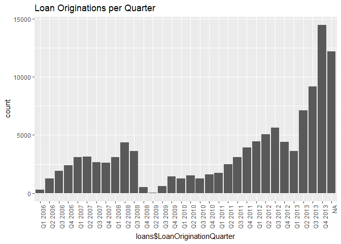

```
## Q1 2006 Q2 2006 Q3 2006 Q4 2006 Q1 2007 Q2 2007 Q3 2007 Q4 2007 Q1 2008
##     315    1254    1934    2403    3079    3118    2671    2592    3074
## Q2 2008 Q3 2008 Q4 2008 Q1 2009 Q2 2009 Q3 2009 Q4 2009 Q1 2010 Q2 2010
##    4344    3602     532       0      13     585    1449    1243    1539
## Q3 2010 Q4 2010 Q1 2011 Q2 2011 Q3 2011 Q4 2011 Q1 2012 Q2 2012 Q3 2012
##    1270    1600    1744    2478    3093    3913    4435    5061    5632
## Q4 2012 Q1 2013 Q2 2013 Q3 2013 Q4 2013    NA's
##    4425    3616    7099    9180   14450   12194
```

*How many loans are they making?* This chart shows the number of loans originated by quarter. This shows that the number of origination increased from 2006 and then things fell off in 2008 to essentially nothing in early 2009 corresponding to their SEC relaunch. The trend has increased since late 2009.

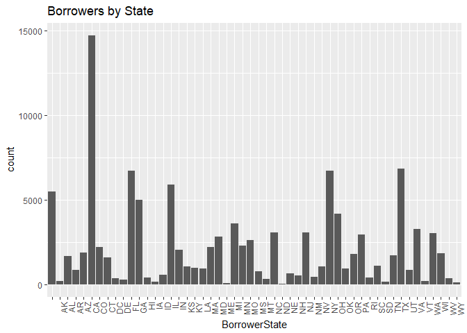

```
##          AK    AL    AR    AZ    CA    CO    CT    DC    DE    FL    GA
##  5515   200  1679   855  1901 14717  2210  1627   382   300  6720  5008
##    HI    IA    ID    IL    IN    KS    KY    LA    MA    MD    ME    MI
##   409   186   599  5921  2078  1062   983   954  2242  2821   101  3593
##    MN    MO    MS    MT    NC    ND    NE    NH    NJ    NM    NV    NY
##  2318  2615   787   330  3084    52   674   551  3097   472  1090  6729
##    OH    OK    OR    PA    RI    SC    SD    TN    TX    UT    VA    VT
##  4197   971  1817  2972   435  1122   189  1737  6842   877  3278   207
##    WA    WI    WV    WY
##  3048  1842   391   150
```

*So where are we making the loans?* It appears that the largest number of loans are made to people in CA. The data also appears to align with the states with higher populations (i.e., CA, FL, NY, TX) originaing more loans

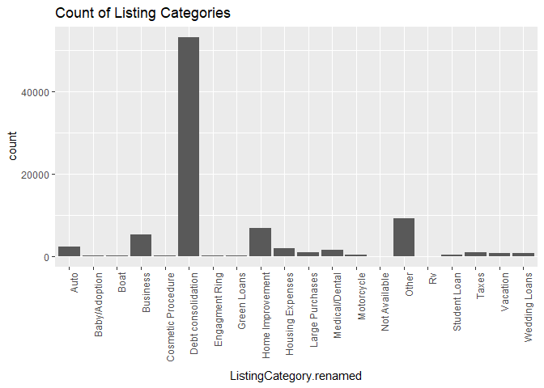

```
##    Length     Class      Mode
##    113937 character character
```

*So what are people borrowing for?* It looks like the majority of the loans are for debt consolidation

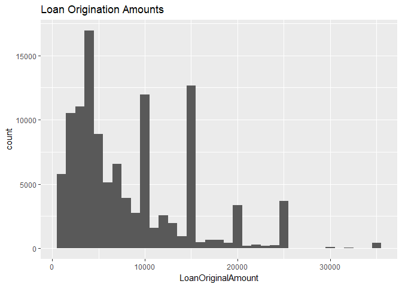

```
##    Min. 1st Qu.  Median    Mean 3rd Qu.    Max.
##    1000    4000    6500    8337   12000   35000
```

*So how much are people borrowing?* It appears that the bulk of the loans are for less than 10,000 dollars with the actual mean of 8,337 dollars. We see possible outliers in the $30K-$35K range

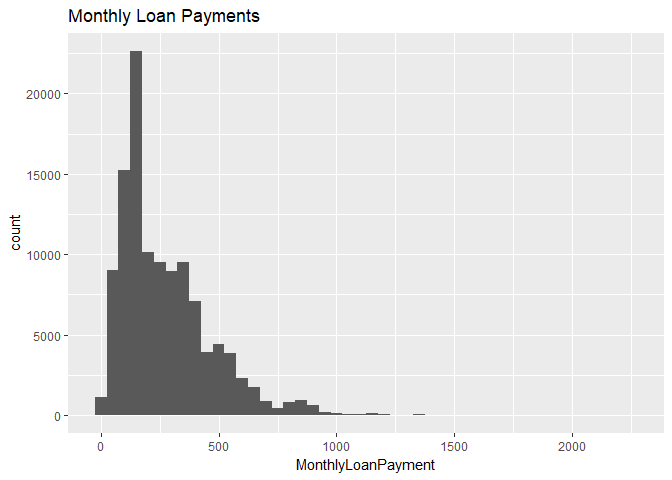

```
##    Min. 1st Qu.  Median    Mean 3rd Qu.    Max.
##     0.0   131.6   217.7   272.5   371.6  2251.5
```

*How much are they paying?* The mean loan payments are $272 with max of 2251.50 per month range.

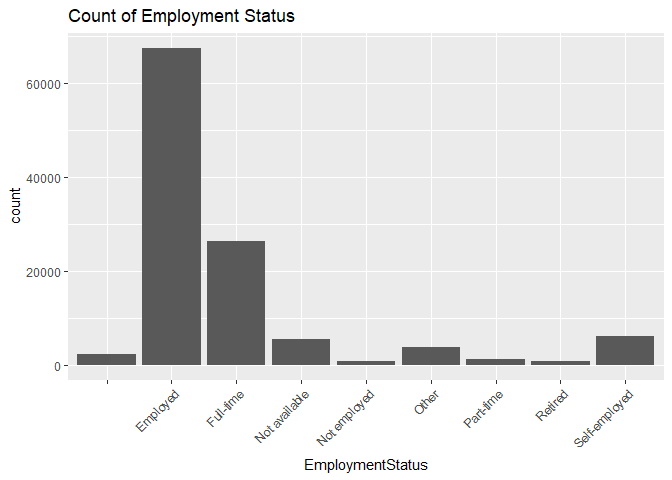

```
##                    Employed     Full-time Not available  Not employed
##          2255         67322         26355          5347           835
##         Other     Part-time       Retired Self-employed
##          3806          1088           795          6134
```

*So are they working?* Most are employed. It would not make much financial sense to loan money to people who are unemployed, though there are a relatively small number of loans to people who are unemployed.

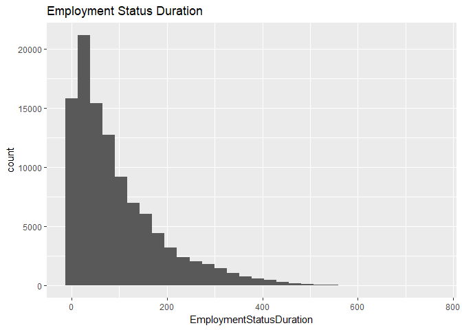

```
##    Min. 1st Qu.  Median    Mean 3rd Qu.    Max.    NA's
##    0.00   26.00   67.00   96.07  137.00  755.00    7625
```

*How long have they been employed?* With bin width set to 24, it appears that most loan recipients are employed in the 24-48 month range, actual mean is 96.

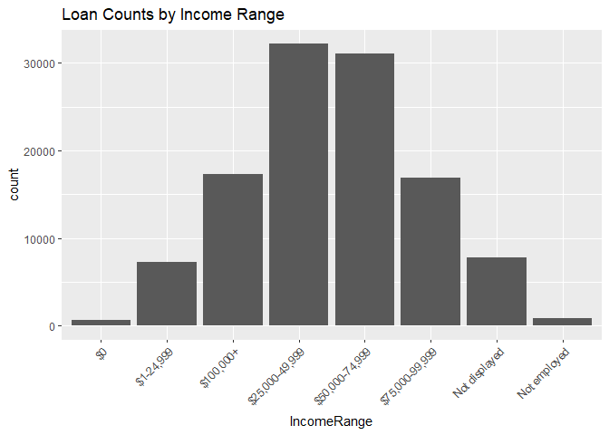

```
##             $0      $1-24,999      $100,000+ $25,000-49,999 $50,000-74,999
##            621           7274          17337          32192          31050
## $75,000-99,999  Not displayed   Not employed
##          16916           7741            806
```

*How much are they earning?* The range goes from zero to $100K and appears to be normally distributed, with most people falling between $25K-$75K

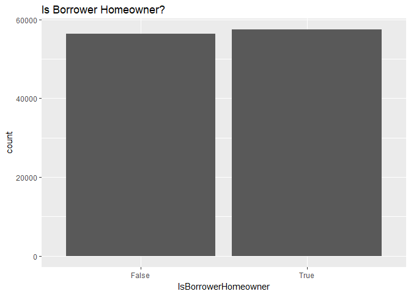

```
## False  True
## 56459 57478
```

*Are they homewoners?* The number of homeowners versus non-homeowners is virtually the same

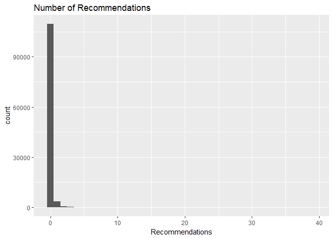

```
##     Min.  1st Qu.   Median     Mean  3rd Qu.     Max.
##  0.00000  0.00000  0.00000  0.04803  0.00000 39.00000
```

*Did they have recommendations?* Most loans requests don’t have recommendations and there is a very tall 0.

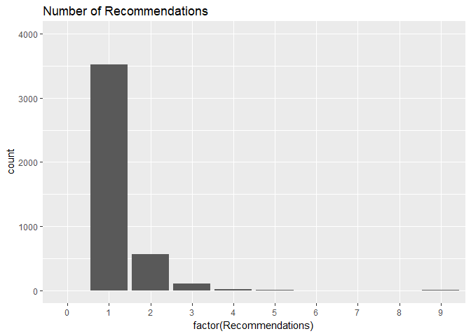

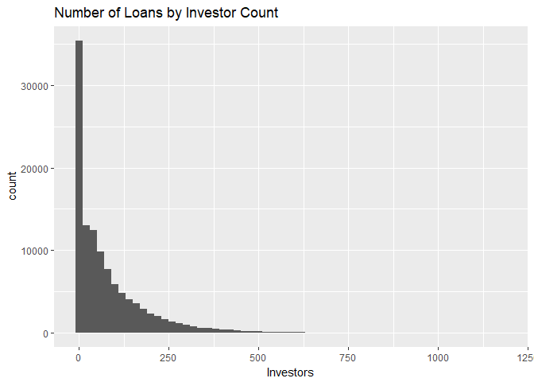

```
##    Min. 1st Qu.  Median    Mean 3rd Qu.    Max.
##    1.00    2.00   44.00   80.48  115.00 1189.00
```

*Did they have investors?* There is single large bar because about 25% of the loans have only a single investor. The average number of investors is about 80, but the max is 1189 which indcates outliers.

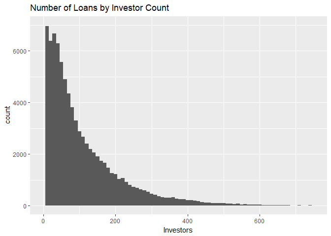

Here we set the x limits to exclude those with only one investor and those above 750 so we can zoom in on the remainder of the distribution.

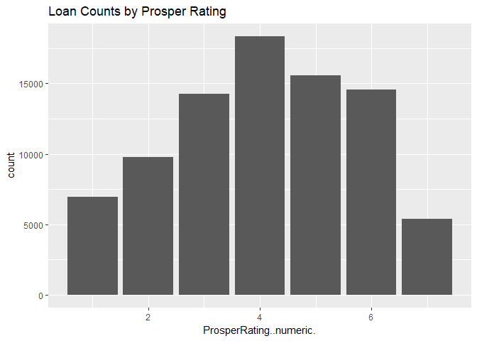

*Are they a good risk?* Next we look at the distribution of the numeric version of the Prosper rating. Lower values are high risk, a value of 4 aligns roughly to an average credit rating. This distribution also appears to be normally distributed

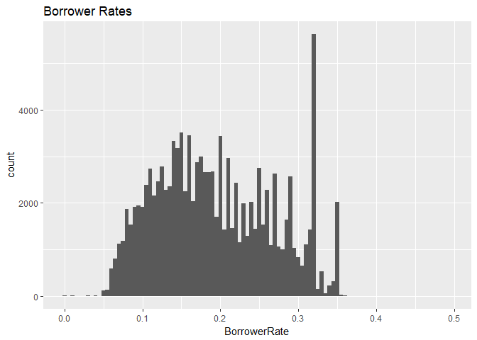

*What rates are they getting?* Borrower Rate range from 0 to .4975. The bulk of the loans seem to be near the 0.2 mark, the majority of the users are in the middle of the risk ratings.

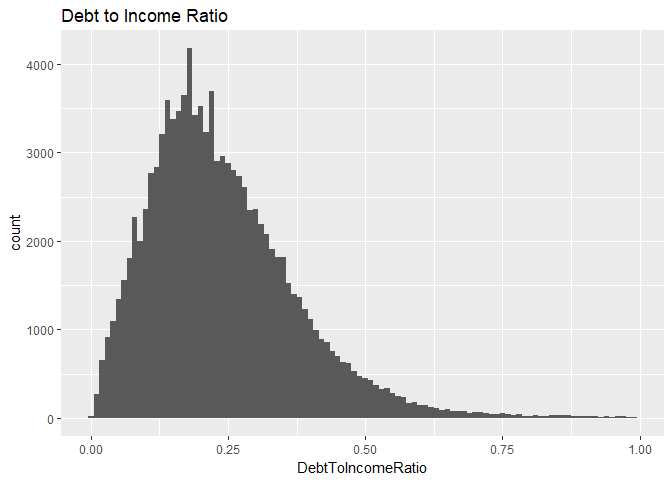

*Let’s look at Debt-to-income-Ratio…* There are some very high debt-to-income ratios, some greater than 10. I decided to filter those and plot ratios less than 1.

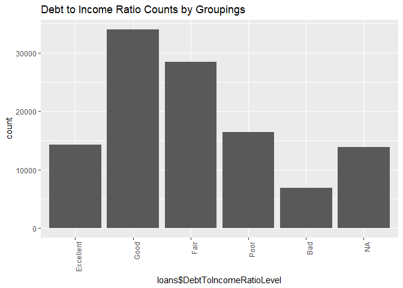

*Another view of Debt-to-income-Ratio…* In this chart I used the custom debt-to-Income ratio levels, with ranges at .10 increments. Most loans fall in the level I characterized as ‘fair’ or better.

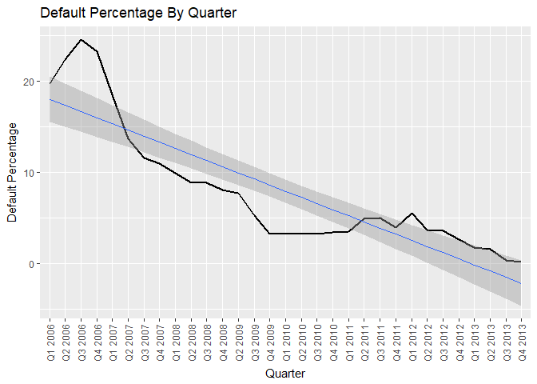

*Are they defaulting on these loans?* Defaults on loans have been in decline, likely due to improved risk determination over time

# Univariate Analysis

### What is the structure of your dataset?

My dataset is made up of 28 of the 81 total variables of the original dataset. I removed the unused variables to make the dataset more manageable for this project.

### What is/are the main feature(s) of interest in your dataset?

I think the ratings (prosper, credit score, etc) and the debt-to-income ratio are of most interest. I think debt income ratio (DTI) can be used as a single measure which comprises other risk measures like card utilization, etc

Investors and their yield, borrowers and their income and rates

### Of the features you investigated, were there any unusual distributions? Did you perform any operations on the data to tidy, adjust, or change the form of the data? If so, why did you do this?

I thought it was odd that loans would be approved for applicants with low credit ratings or for people who were unemployed. There were missing values many seemed appropriate given the loan lifecycle or the dates of certain implementations (some things did not exist prioer to 2009). There seemed to be a large number Outliers in the dataset that needed to be filtered in some cases. I did not tidy the data by segmenting categories of observations but I took some steps to address the default way that dates and factors were imported.

# Bivariate Plots Section

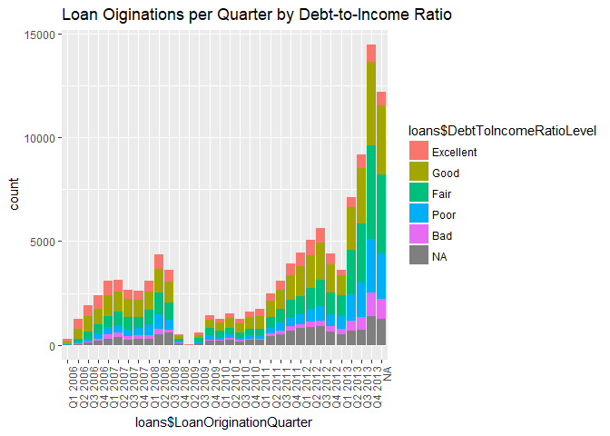

*Debt to Income Ratio Levels per loans originated.* Here we see breakdown of DTI across loan originations.

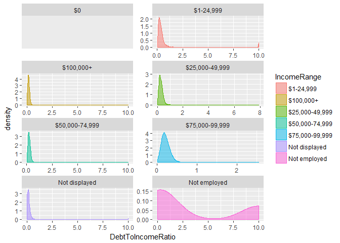

*Debt-to-income-ratio per income range.* This chart shows the breakout of DTI ratio in relationship to income range.

[figure not shown]

*Loan origination amounts.* This series of boxplot shows the relative distributions of loan categories. A boxlot showsa graphicalpicture of the five number summary: minimum, first quartile, median, third quartile, and maximum. This view also shows potential outliers.

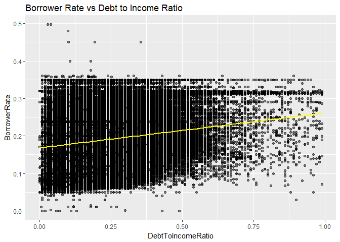

*Debt-to-Income-Ratio versus Borrower Rate*. As expected higer risk is associated with a person having more debt, higher risk resuts is a higher borrower rates

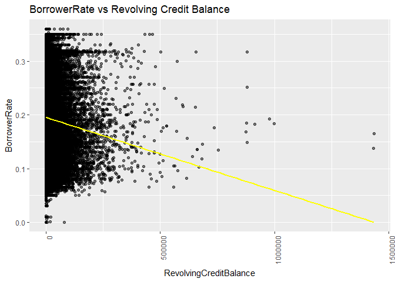

*Revolving Credit Balance versus Borrower Rate*. This appears to be counter intuitive. One would expect th rate to be higher if a person has a large revolving credit balance. This oculd be due to outliers and worther of further inspection.

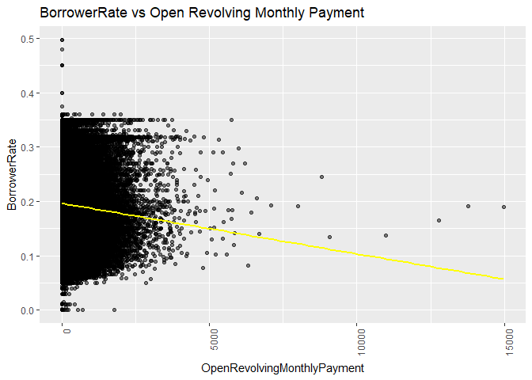

*Open Revolving Monthly Payment versus Borrower Rate.* This appears to be counter intuitive. One would expect th rate to be higher if a person has a large revolving monthly payment. This oculd be due to outliers and worther of further inspection.

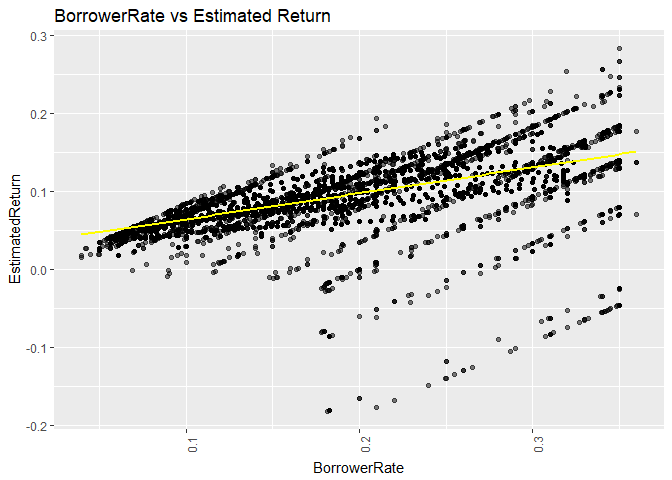

*Estimated Return versus Borrower Rate.* There is a positive relationship between Borrower Rate and Estimated return.

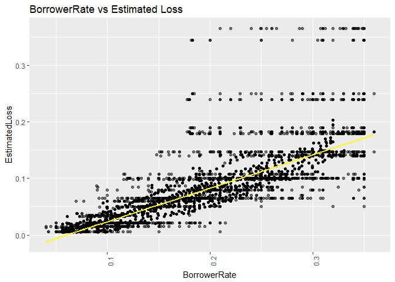

*Estimated Loss versus Borrower Rate.* As one would expect Borrower Rate and affects both expected return and estimated loss.

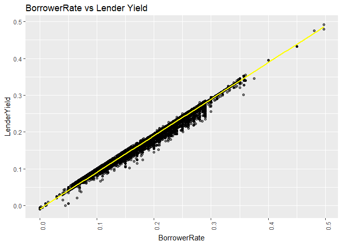

*Lender Yield versus Borrower Rate.* Appears to be a very strong relationship between Borrower rate and Lender Yield

[figure not shown]

*Monthly Income versus Deb-to-Income-Ratio.* A lot of overplotting here but I decided to leave this chart in, Open points helped somewhat along with the regression line. There also appeared to be a lot of outliers in stated monthly income.